# Board Game Geek Rating Prediction Based on Comments.

# Lets see word clouds for positive words and negative words

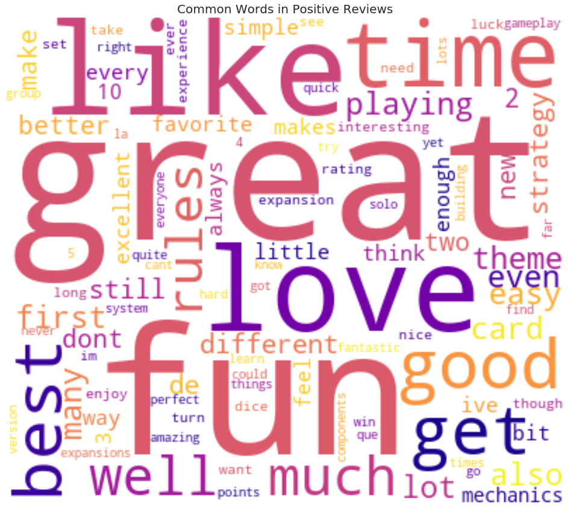

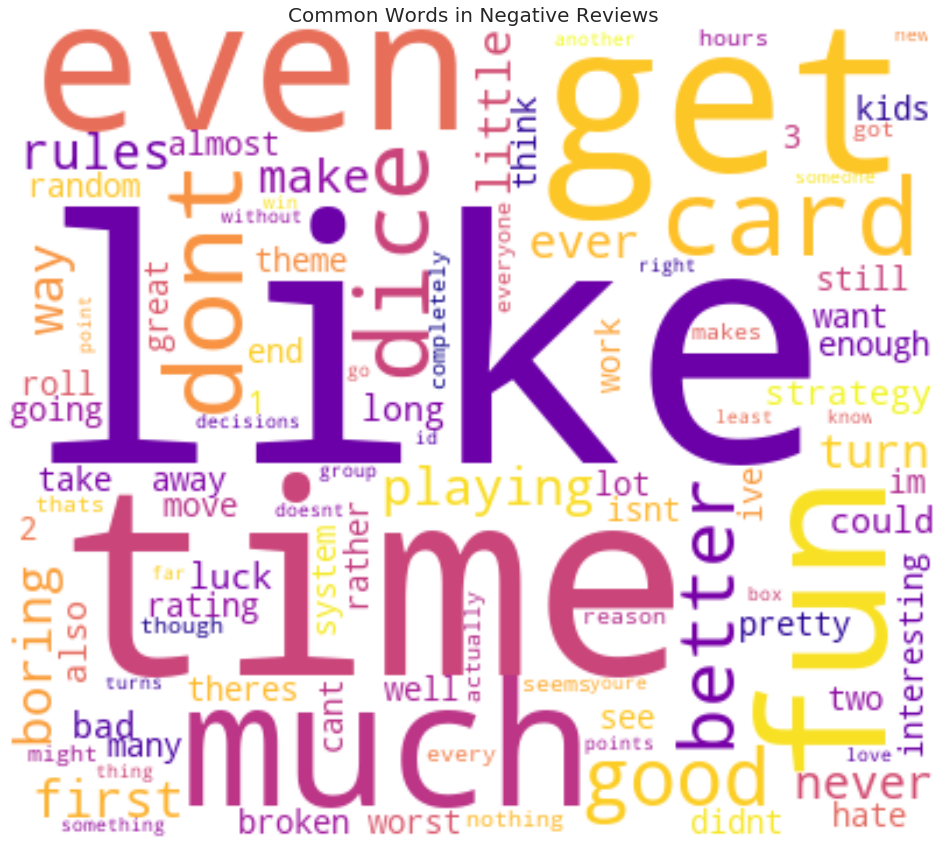

```python
from wordcloud import WordCloud
from collections import Counter

neg = review_data3.loc[review_data3['rating'] < 3]
pos = review_data3.loc[review_data3['rating'] > 8]


words = Counter([w for w in " ".join(pos['cleaned']).split()])

wc = WordCloud(width=400, height=350,colormap='plasma',background_color='white').generate_from_frequencies(dict(words.most_common(100)))
plt.figure(figsize=(20,15))
plt.imshow(wc, interpolation='bilinear')
plt.title('Common Words in Positive Reviews', fontsize=20)
plt.axis('off');
plt.show()


words = Counter([w for w in " ".join(neg['cleaned']).split()])

wc = WordCloud(width=400, height=350,colormap='plasma',background_color='white').generate_from_frequencies(dict(words.most_common(100)))
plt.figure(figsize=(20,15))
plt.imshow(wc, interpolation='bilinear')
plt.title('Common Words in Negative Reviews', fontsize=20)
plt.axis('off');
plt.show()
```

- A word cloud of positive (rating > 8) and negative (rating < 3) reviews was generated as above. The positive word cloud contains mostly positive 100 words, the negative word cloud contains a mix of 100 words that are not necessarily negative

# lets check mean, median and mode of rating of our unbalced sample

```python
print('Mean: ', review_data3.rating.mean())
print('Median: ', review_data3.rating.median())
print('Mode: ', review_data3.rating.mode())
```

```
Mean:  6.856034572666648
Median:  7.0
Mode:  0    7.0
dtype: float64
```

# Now define Necessary function to calculate RMSE,Weighted RMSE MAF and model assessment

```python
def calc_rmse(errors, weights=None):
    n_errors = len(errors)
    if weights is None:
        result = sqrt(sum(error ** 2 for error in errors) / n_errors)
    else:
        result = sqrt(sum(weight * error ** 2 for weight, error in zip(weights, errors)) / sum(weights))
    return result

#if the score is far from mean (high or low scores), weight those reviews and ratings more when assessing model accuracy
def calc_weights(scores):
    peak = 6.851
    return tuple((10 ** (0.3556 * (peak - score))) if score < peak else (10 ** (0.2718 * (score - peak))) for score in scores)


def assess_model( model_name, test, predicted):
    error = test - predicted
    rmse = calc_rmse(error)
    mae = mean_absolute_error(test, predicted)
    weights = calc_weights(test)
    weighted_rmse = calc_rmse(error, weights = weights)


    print(model_name)
    print('RMSE:',rmse)
    print('Weighed RMSE:', weighted_rmse)
    print('MAE:', mae)
```

# Lets do MNB model to predict the rating based on comments

The 30 thousands unbalanced data was splitted as train and test set for the modeling, then pipeline was used to tune the model.

- count_vectorizer - Breaks up the text into a matrix with each word (called "token" in NLP) being the column of the matrix and the value being the count of occurences.
- ngram_range - Optional parameter to extract the text in groups of 2 or more words together. This is useful because the modifiers such as 'not' can be used to change the following word's meaning.
- stopwords - Removes any words from the stopwords list created in the data exploration step.
- lowercase - Converts all text into lowercase.
- tfidf_transformer - Weighs terms by importance to help with feature selection.
- classifier - two types of models was used, multi-class classification, Multinomial NB and LinearSVC

Model performance will be judged with the accuracy value

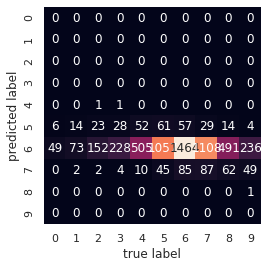

```
Multinomial NB
RMSE: 1.7390785011429706
Weighed RMSE: 3.8230391348432726
MAE: 1.292360885

****Test accuracy is 26.866666666666667
```

```python
X_train, X_test, y_train, y_test = train_test_split(review_data3.cleaned, review_data3.rating, random_state=44,test_size=0.20)

model_nb = Pipeline([
    ('count_vectorizer', CountVectorizer(lowercase = True, stop_words = stopwords.words('english'))),
    ('tfidf_transformer',  TfidfTransformer()), #weighs terms by importance to help with feature selection
    ('classifier', MultinomialNB()) ])

model_nb.fit(X_train,y_train.astype('int'))
labels = model_nb.predict(X_test)
mat = confusion_matrix(y_test.astype('int'), labels)
sns.heatmap(mat.T, square=True, annot=True, fmt='d', cbar=False )
plt.xlabel('true label')
plt.ylabel('predicted label');
plt.show()

assess_model("Multinomial NB", y_test,labels)
acc = accuracy_score(y_test.astype('int'),labels, normalize=True) * float(100)
print('\n****Test accuracy is',(acc))
```

# The accuracy of MNB model is 27 % for unbalanced sample but the problem of the above model is that it did not predict rating 1-4 and 8-9 (confusion Matrix), it has only predicted around the average value of the rating (6.85)

# Lets do MNB model with N-grams to predict the rating based on comments

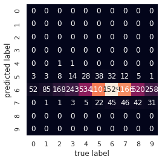

```
Multinomial NB n-grams 1-2
RMSE: 1.7543120303424782
Weighed RMSE: 3.871180517324755
MAE: 1.3020942183333333

****Test accuracy is 26.883333333333333
```

```python
#Experimented with adding different numbers of n-grams, 1-2 seems to have best performance
model_nb2 = Pipeline([
    ('count_vectorizer', CountVectorizer( ngram_range=(1,2), lowercase = True, stop_words = stopwords.words('english'))),
    ('tfidf_transformer',  TfidfTransformer()), #weighs terms by importance to help with feature selection
    ('classifier', MultinomialNB()) ])

model_nb2.fit(X_train,y_train.astype('int'))
labels = model_nb2.predict(X_test)
mat = confusion_matrix(y_test.astype('int'), labels)
sns.heatmap(mat.T, square=True, annot=True, fmt='d', cbar=False )
plt.xlabel('true label')
plt.ylabel('predicted label');
plt.show()

assess_model("Multinomial NB n-grams 1-2", y_test,labels)
acc = accuracy_score(y_test.astype('int'),labels, normalize=True) * float(100)
print('\n****Test accuracy is',(acc))
```

# The accuracy of MNB model with N-grams is almost same of MNB (27 %) for unbalanced sample but the problem of the above model is that it also did not predict rating 1-4 and 8-9 (confusion Matrix), it has only predicted around the average value of the rating (6.85).

# Lets check with different hyperparameter for MNB Model

```python
# Convert the data in vector fpormate
tf_idf_vect = TfidfVectorizer(ngram_range=(1,2))
tf_idf_train = tf_idf_vect.fit_transform(X_train)
tf_idf_test = tf_idf_vect.transform(X_test)

alpha_range = list(np.arange(0,30,1))
len(alpha_range)
```

```
30
```

# Take different values of alpha in cross validation and finding the accuracy score

```python
from sklearn.naive_bayes import MultinomialNB
y_train=y_train.astype('int')

alpha_scores=[]

for a in alpha_range:
    clf = MultinomialNB(alpha=a)
    scores = cross_val_score(clf, tf_idf_train, y_train, cv=5, scoring='accuracy')
    alpha_scores.append(scores.mean())
    print(a,scores.mean())
```

```
0 0.2229166666666667
1 0.2659166666666667
2 0.2637083333333333
3 0.26308333333333334
4 0.26279166666666665
5 0.2628333333333333
6 0.2628749999999999
7 0.26266666666666666
8 0.26266666666666666
9 0.2625833333333333
10 0.26245833333333335
11 0.26241666666666663
12 0.2622083333333333
13 0.2622083333333333
14 0.2622083333333333
15 0.262125
16 0.262125
17 0.26216666666666666
18 0.26216666666666666
19 0.2620416666666666
20 0.262
21 0.262
22 0.2619166666666667
23 0.2619166666666667
24 0.2619166666666667
25 0.2619166666666667
26 0.2619166666666667
27 0.2619166666666667
28 0.2619166666666667
29 0.2619166666666667
```

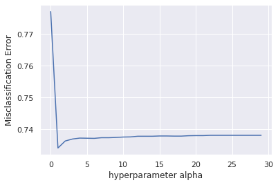

```python
# Plot b/w misclassification error and CV mean score.
import matplotlib.pyplot as plt

MSE = [1 - x for x in alpha_scores]


optimal_alpha_bnb = alpha_range[MSE.index(min(MSE))]

# plot misclassification error vs alpha
plt.plot(alpha_range, MSE)

plt.xlabel('hyperparameter alpha')
plt.ylabel('Misclassification Error')
plt.show()
```

```python
optimal_alpha_bnb
```

```
1
```

- It is found that hyper-parameter 1 performs best to predict the rating,our MNB automatically use hyperparameter 1. so already did this model.

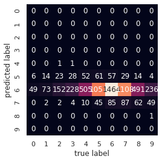

```
Multinomial NB
RMSE: 1.7390785011429706
Weighed RMSE: 3.8230391348432726
MAE: 1.292360885

****Test accuracy is 26.866666666666667
```

```python
model_nb = Pipeline([
    ('count_vectorizer', CountVectorizer(lowercase = True, stop_words = stopwords.words('english'))),
    ('tfidf_transformer',  TfidfTransformer()), #weighs terms by importance to help with feature selection
    ('classifier', MultinomialNB(alpha=optimal_alpha_bnb)) ])

model_nb.fit(X_train,y_train.astype('int'))
labels = model_nb.predict(X_test)
mat = confusion_matrix(y_test.astype('int'), labels)
sns.heatmap(mat.T, square=True, annot=True, fmt='d', cbar=False )
plt.xlabel('true label')
plt.ylabel('predicted label');
plt.show()

assess_model("Multinomial NB", y_test,labels)
acc = accuracy_score(y_test.astype('int'),labels, normalize=True) * float(100)
print('\n****Test accuracy is',(acc))
```

# We have already done this using MNB model.

# Lets try Linear SVC Model

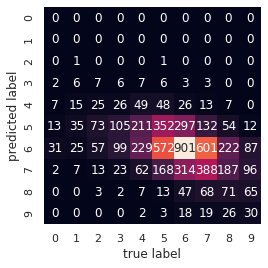

```
Linear SVC model
RMSE: 1.6323990116199172
Weighed RMSE: 3.4626254301869106
MAE: 1.190857885

****Test accuracy is 29.95
```

```python
model_svc = make_pipeline(TfidfVectorizer(ngram_range=(1,3)), svm.SVC(kernel="linear",probability=True))
model_svc.fit(X_train, y_train.astype('int'))
labels = model_svc.predict(X_test)

mat = confusion_matrix(y_test.astype('int'), labels)
sns.heatmap(mat.T, square=True, annot=True, fmt='d', cbar=False )
plt.xlabel('true label')
plt.ylabel('predicted label');
plt.show()

assess_model("Linear SVC model", y_test,labels)
acc = accuracy_score(y_test.astype('int'),labels, normalize=True) * float(100)
print('\n****Test accuracy is',(acc))
```

# SVC model performs better than any others model as Accuracy= 29% which is greater than MNB and MNB-N-grams

# All the above models are simply predicting reviews around the average rating accept SVC model. MNB and MNB-N-grams did not predict any low reviews. This is because the training data is so unbalanced that it can't detect a negative review.

# To overcome this situation. we need to create a balnace data set as the subset of orinal data to train the model, then we need to use that model to predict on the unbalanced sample. In this case, we will train SVC model as it performs better than other two.

# Let us create a Balanced sample that have 2000 sample from each rating

```python
review_data2.head()
rating1_subset = review_data2[review_data2['rating']==1]
rating1_subset.head()

# Slect 100 sample that have rating =1
r1=rating1_subset.sample(2000)
r1.head()


rating2_subset = review_data2[review_data2['rating']==2]
rating2_subset.head()
# Slect 100 sample that have rating =2
r2=rating2_subset.sample(2000)
r2.head()

rating3_subset = review_data2[review_data2['rating']==3]
rating3_subset.head()
# Slect 100 sample that have rating =3
r3=rating3_subset.sample(2000)
r3.head()

rating4_subset = review_data2[review_data2['rating']==4]
rating4_subset.head()
# Slect 100 sample that have rating =4
r4=rating4_subset.sample(2000)
r4.head()

rating5_subset = review_data2[review_data2['rating']==5]
rating5_subset.head()
# Slect 100 sample that have rating =5
r5=rating5_subset.sample(2000)
r5.head()

rating6_subset = review_data2[review_data2['rating']==6]
rating6_subset.head()
# Slect 100 sample that have rating =6
r6=rating6_subset.sample(2000)
r6.head()

rating7_subset = review_data2[review_data2['rating']==7]
rating7_subset.head()
# Slect 100 sample that have rating =7
r7=rating7_subset.sample(2000)
r7.head()

rating8_subset = review_data2[review_data2['rating']==8]
rating8_subset.head()
# Slect 100 sample that have rating =8
r8=rating8_subset.sample(2000)
r8.head()

rating9_subset = review_data2[review_data2['rating']==9]
rating9_subset.head()
# Slect 100 sample that have rating=9
r9=rating9_subset.sample(2000)
r9.head()

rating10_subset = review_data2[review_data2['rating']==10]
rating10_subset.head()
# Slect 100 sample that have rating=10
r10=rating10_subset.sample(2000)
r10.head()
```

|  | user | rating | comment | ID | name |
| --- | --- | --- | --- | --- | --- |
| 4274325 | Misiodziej | 10.0 | Bw:5 | 127023 | Kemet |
| 2507106 | boulette de steak | 10.0 | It's my favorite game !!! Without doubt the be... | 42 | Tigris & Euphrates |
| 8835445 | Kejben | 10.0 | Great two player strategy game with a lot of l... | 82421 | Summoner Wars: Phoenix Elves vs Tundra Orcs |
| 3430448 | Koert | 10.0 | Excellent epic complex card-driven civilisatio... | 25613 | Through the Ages: A Story of Civilization |
| 5067212 | Hummingbirdmagic | 10.0 | I have a great interest in history, especially... | 171668 | The Grizzled |

# Now combined all 20,000 samples with 2000 samples for each rating-**Balanced Sample**

```python
review_balance=df = r1.append([r2, r3,r4,r5,r6,r7,r8,r9,r10])
review_balance.head()
```

|  | user | rating | comment | ID | name |
| --- | --- | --- | --- | --- | --- |
| 681566 | Numskull | 1.0 | A twelve hour war game disguised as a civiliza... | 3870 | 7 Ages |
| 462726 | mgringo | 1.0 | N/C. not worth it. | 16398 | War |
| 6491275 | newkillerstar27 | 1.0 | Far too long and far too random. | 24310 | The Red Dragon Inn |
| 9558637 | LosSchabossDragon | 1.0 | The whole theme is distasteful. Ok a lot of em... | 65282 | Tanto Cuore |
| 2412076 | lortelars | 1.0 | An incredibly boring game with "roll to move" ... | 1406 | Monopoly |

```python
review_balance.shape
```

```
(20000, 5)
```

# Making lowercase, removing punctuation and stop words from Balanced sample

```python
#lowercase and remove punctuation
review_balance['cleaned'] = review_balance['comment'].str.lower().apply(lambda x:''.join([i for i in x if i not in string.punctuation]))

# stopword list to use
stopwords_list = stopwords.words('english')
stopwords_list.extend(('game','play','played','players','player','people','really','board','games','one','plays','cards','would'))

stopwords_list[-10:]

#remove stopwords
review_balance['cleaned'] = review_balance['cleaned'].apply(lambda x: ' '.join([word for word in x.split() if word not in (stopwords_list)]))
review_balance.head()
```

|  | user | rating | comment | ID | name | cleaned |
| --- | --- | --- | --- | --- | --- | --- |
| 681566 | Numskull | 1.0 | A twelve hour war game disguised as a civiliza... | 3870 | 7 Ages | twelve hour war disguised civilization dominat... |
| 462726 | mgringo | 1.0 | N/C. not worth it. | 16398 | War | nc worth |
| 6491275 | newkillerstar27 | 1.0 | Far too long and far too random. | 24310 | The Red Dragon Inn | far long far random |
| 9558637 | LosSchabossDragon | 1.0 | The whole theme is distasteful. Ok a lot of em... | 65282 | Tanto Cuore | whole theme distasteful ok lot employers must ... |
| 2412076 | lortelars | 1.0 | An incredibly boring game with "roll to move" ... | 1406 | Monopoly | incredibly boring roll move bane mechanics com... |